```python
import numpy as np
import pandas as pd
import matplotlib.pyplot as plt
import zipfile
from PIL import Image
import xml.etree.ElementTree as ET

from tensorflow.keras.models import Model
from tensorflow.keras.layers import Input, Dense, Conv2D, MaxPooling2D, UpSampling2D, Reshape, BatchNormalization
from tensorflow.keras.preprocessing.image import ImageDataGenerator
from tensorflow.keras.callbacks import LearningRateScheduler
from tensorflow.keras.optimizers import SGD, Adam


import os

DATA_PATH = "data/"
```

# Intro

In this project we will use use dog images from the [Kaggle Generative Dog Images Contest](https://www.kaggle.com/competitions/generative-dog-images/data).

We have about 25000 images in the shape of 64x64x3.

Using these characteristics, we will use the attributes to create our own dog images.

## Data generation

First, our data is contained within zipped files. Thus, we need to extract both the images and the annotations from their respective zipped directories

```python
UNZIPPED_PATH = os.path.join(DATA_PATH, "unzipped_main")
if not os.path.exists(UNZIPPED_PATH):
  with zipfile.ZipFile(os.path.join(DATA_PATH, "generative-dog-images.zip"),"r") as zip_ref:
      zip_ref.extractall(UNZIPPED_PATH)
```

```python
DOGS_PATH = os.path.join(DATA_PATH, "dogs/")
if not os.path.exists(os.path.join(DOGS_PATH, "imgs/")):
  with zipfile.ZipFile(os.path.join(UNZIPPED_PATH, "all-dogs.zip"),"r") as zip_ref:
      zip_ref.extractall(os.path.join(DOGS_PATH, "imgs/"))
```

```python
if not os.path.exists(os.path.join(DOGS_PATH, "annotations/")):
  with zipfile.ZipFile(os.path.join(UNZIPPED_PATH, "Annotation.zip"),"r") as zip_ref:
      zip_ref.extractall(os.path.join(DOGS_PATH, "annotations/"))
```

```python
IMAGES_PATH = "data/dogs/imgs/all-dogs/"
ANNOTATIONS_PATH = "data/dogs/annotations/Annotation/"
np.random.seed(978058)
random_dim = 128

breeds = os.listdir(ANNOTATIONS_PATH)
IMAGES = os.listdir(IMAGES_PATH)
```

# Normalizing Images

Many of the picutres within the data set contain images what have dogs. Not all of the images consist of only dogs. To make sure we are training dogs, we need to crop the images so they are only modeling the characteristics of the dogs. Removing this noise will provide consistency in our model.

First, we iterate over each image until we fid one that matches the breed we are searchine for. The *Annotations* directory contain the following:

- the size of the image
- the type of dog that is in the image
- the dimensionsions that contain the dog's image

We then use these to crop the image and gain new features of our cropped image.

```python
idx = 0; breed_names = []
breed_images = np.zeros((25000,64,64,3))

#Overall, used to get cropped images that focuses dogs
for breed in breeds:
    for dog in os.listdir(ANNOTATIONS_PATH+breed):

        # A few images errored out so I removed from training set
        try: img = Image.open(IMAGES_PATH + dog + '.jpg')
        except: continue

        #Find location of dog within image and what type
        tree = ET.parse(ANNOTATIONS_PATH + breed + '/' + dog)
        root = tree.getroot()
        objects = root.findall('object')

        #crop images so they only return images of the dogs
        for aobject in objects:
            boundaries = aobject.find('bndbox')
            xmin = int(boundaries.find('xmin').text)
            ymin = int(boundaries.find('ymin').text)
            xmax = int(boundaries.find('xmax').text)
            ymax = int(boundaries.find('ymax').text)
            w = np.min((xmax - xmin, ymax - ymin))
            img2 = img.crop((xmin, ymin, xmin+w, ymin+w))
            img2 = img2.resize((64,64), Image.ANTIALIAS)
            breed_images[idx,:,:,:] = np.asarray(img2)
            breed_names.append(breed)
            idx += 1
```

```python
#Save arrays for quick loading
import pickle
PICKLED_PATH = "data/pickled/"
if not os.path.exists(PICKLED_PATH):
    os.makedirs(PICKLED_PATH)
with open(PICKLED_PATH + "cropped_imgs_arr", 'wb') as img_arr:
  pickle.dump(breed_images, img_arr)
```

```python
with open(PICKLED_PATH + "cropped_imgs_names", 'wb') as img_names:
  pickle.dump(breed_names, img_names)
```

## Viewing Images

Here we'll just take a look at a a few of our pictures and the labels associated with them.

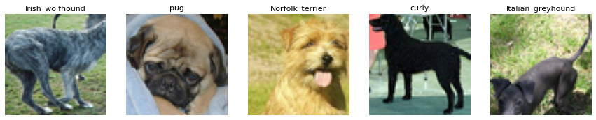

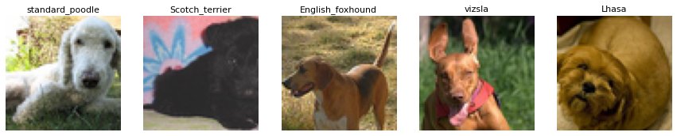

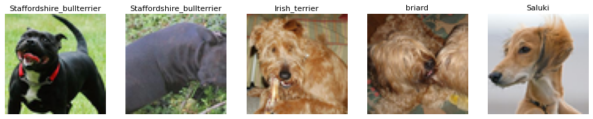

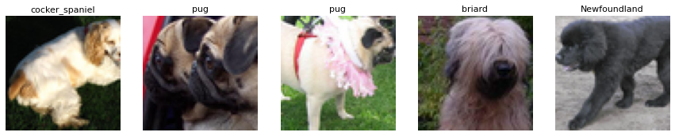

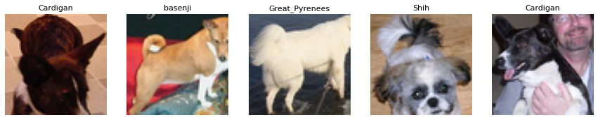

```python
i = np.random.randint(0,idx,25)
for k in range(5):
    plt.figure(figsize=(15,3))
    for j in range(5):
        plt.subplot(1,5,j+1)
        img = Image.fromarray( breed_images[i[k*5+j],:,:,:].astype('uint8') )
        plt.axis('off')
        plt.title(breed_names[i[k*5+j]].split('-')[1],fontsize=11)
        plt.imshow(img)
    plt.show()
```

# Model Building

- We need to create a deep neural network that is deep enough to find the important features of a dog image
- Here's why certain parameters were used
  - We use **elu** as an activation function to diminish the vanishing gradient effect
  - **Padding** is parameterized as *same* to prevent our filter from shrinking the image. We need our images to output as the same size as the input. Hence, why we also use **Reshape** layers

```python
#Build Generative Network
nn_input = Input((10000,))
layer = Dense(2048, activation='elu')(nn_input)
layer = Reshape((8,8,32))(layer)
layer = Conv2D(128, (3, 3), activation='elu', padding='same')(layer)
layer = UpSampling2D((2, 2))(layer)
layer = Conv2D(64, (3, 3), activation='elu', padding='same')(layer)
layer = UpSampling2D((2, 2))(layer)
layer = Conv2D(32, (3, 3), activation='elu', padding='same')(layer)
layer = UpSampling2D((2, 2))(layer)
output_layer = Conv2D(3, (3, 3), activation='sigmoid', padding='same')(layer)

model_nn = Model(nn_input, output_layer)
model_nn.compile(optimizer=Adam(lr=0.003), loss='binary_crossentropy')

model_nn.summary()
```

```
Model: "model"
_________________________________________________________________
 Layer (type)                Output Shape              Param #
=================================================================
 input_1 (InputLayer)        [(None, 10000)]           0
```

[output not shown]

```
 dense (Dense)               (None, 2048)              20482048

 reshape (Reshape)           (None, 8, 8, 32)          0

 conv2d (Conv2D)             (None, 8, 8, 128)         36992

 up_sampling2d (UpSampling2D  (None, 16, 16, 128)      0
 )

 conv2d_1 (Conv2D)           (None, 16, 16, 64)        73792

 up_sampling2d_1 (UpSampling  (None, 32, 32, 64)       0
 2D)

 conv2d_2 (Conv2D)           (None, 32, 32, 32)        18464

 up_sampling2d_2 (UpSampling  (None, 64, 64, 32)       0
 2D)

 conv2d_3 (Conv2D)           (None, 64, 64, 3)         867

=================================================================
Total params: 20,612,163
Trainable params: 20,612,163
Non-trainable params: 0
_________________________________________________________________
```

```python
# Train Model
idx = np.random.randint(0,idx,10000)
train_y = breed_images[idx,:,:,:]/255.
train_X = np.zeros((10000,10000))
for i in range(10000): train_X[i,i] = 1
```

```python
h = model_nn.fit(train_X, train_y, epochs = 5, batch_size=256, callbacks=[annealer], verbose=1)
```

[output not shown]